# Module 2 Assignment

## Data Source

The data is from one of my Python classes last semester. My professor [Brian C. Keegan](http://www.brianckeegan.com/) wrote the function that fetches the page view and the revision data of an article from the Wikipedia. I chose the 'Coronavirus disease 2019' Wikipedia article and did all the data cleaning work and exported the data to a new CSV file to do the visualization for this assignment.

## Motivation and Research Question

I chose 'Coronavirus disease 2019' Wikipedia article to analyze. Covid-19 pandemic is known to have erupted in China at the end of 2019. According to statistics from The New York Times, there were 88 new cases in the United States on March 1st, and the number of new cases continued to rise over time. On June 16th, the daily number of new cases even reached 75000.

The number of page revisions may show when people began to pay attention to the Covid-19. Because more editions mean more awareness and updates about the virus. We can probably see whether people in the world(at least for people who speak English) began to learn the Covid-19 when the pandemic broke out in China, or they started to learn it when the Covid-19 appeared and broke out all over the world.

Therefore, my research question is: by looking at the Wikipedia revision data, when did people start to pay attention to the Covid-19 and whether it is related to the number of new cases?

## Load Libraries

```python
# Data processing
import pandas as pd

# Visualization
import altair as alt

%matplotlib inline
import matplotlib.pyplot as plt
import seaborn as sb
```

## Load Data

```python
# Upload the dataset to a pandas dataframe
revision_data = pd.read_csv("wiki_pageviews.csv",parse_dates=['timestamp'])

# Inspect data, I will explain some columns later
revision_data.head()
```

|  | revid | parentid | user | userid | timestamp | size | sha1 | comment | anon | sha1hidden | page | date | weekday | hour | diff | lag | age |
| --- | --- | --- | --- | --- | --- | --- | --- | --- | --- | --- | --- | --- | --- | --- | --- | --- | --- |
| 0 | 939272928 | 0 | FungTzeLong | 20330199 | 2020-02-05 12:30:37+00:00 | 154 | 0d6bc2cef481de66e8719abe65af74c3aa9d12c3 | [[WP:AES\|←]]Created page with ''''2019-nCoV Ac... | NaN | NaN | Coronavirus disease 2019 | 2020-02-05 | 2 | 12 | NaN | NaN | NaN |
| 1 | 939273303 | 939272928 | FungTzeLong | 20330199 | 2020-02-05 12:34:33+00:00 | 245 | bc42108031744df606b436b14489e7aefa24618f | NaN | NaN | NaN | Coronavirus disease 2019 | 2020-02-05 | 2 | 12 | 91.0 | 0.065556 | 0.065556 |
| 2 | 939273460 | 939273303 | FungTzeLong | 20330199 | 2020-02-05 12:36:23+00:00 | 359 | 3ffb098bf4b826b99e377dd637a0ff499742fae3 | NaN | NaN | NaN | Coronavirus disease 2019 | 2020-02-05 | 2 | 12 | 114.0 | 0.030556 | 0.096111 |
| 3 | 939273791 | 939273460 | FungTzeLong | 20330199 | 2020-02-05 12:39:21+00:00 | 520 | e83a66d526c2f4db5a1e55e23214b9d3ac7bda38 | NaN | NaN | NaN | Coronavirus disease 2019 | 2020-02-05 | 2 | 12 | 161.0 | 0.049444 | 0.145556 |
| 4 | 939276524 | 939273791 | FungTzeLong | 20330199 | 2020-02-05 13:09:21+00:00 | 520 | e83a66d526c2f4db5a1e55e23214b9d3ac7bda38 | Fungchilong moved page [[2019-nCoV Acute Respi... | NaN | NaN | Coronavirus disease 2019 | 2020-02-05 | 2 | 13 | 0.0 | 0.500000 | 0.645556 |

## Visualization

### Scatter plot

Firstly, because the Altair can't load more than 5000 record of data, so I need to drop some rows from my original csv file.

I created a new column called 'month' for the visualization. Also, the column "lag" means the time elapsed since the previous edit, and the unit is in hours. The column "diff" is the change in the web page "size" since the last revision. I will make a scatter plot of these two columns.

```python
clean_data=revision_data[revision_data.index<5000]
clean_data['month'] = clean_data['timestamp'].dt.month
```

```python
alt.Chart(clean_data).mark_circle(clip=True,size=30,opacity=0.5).encode(
    alt.X('lag',scale=alt.Scale(domain=(0, 40))),
    alt.Y('diff',scale=alt.Scale(domain=(-1500, 1500))),
    color = alt.Color("month", scale=alt.Scale(scheme="spectral")),
).properties(
    width=400,
    height=400
)
```

[interactive chart not shown]

#### Interpretation and Disccusion

However, because these points are overlaping each other in the scatter plot, it's hard to see which month has the most changes. So in the next visualization, let's make a line graph with the time line to explore the trend of the revisions.

### Line Plot

I used pandas's groupby function to count the number of revisions by day and created a line plot

```python
daily_gb = revision_data.groupby(pd.Grouper(key='timestamp',freq='1D'))

daily_rev_counts = daily_gb.agg({'sha1':'count'})

#rename column
daily_rev_counts = daily_rev_counts.rename(columns={'sha1': 'counts'})
daily_rev_counts.head()
```

| timestamp | counts |
| --- | --- |
| 2020-02-05 00:00:00+00:00 | 41 |
| 2020-02-06 00:00:00+00:00 | 8 |
| 2020-02-07 00:00:00+00:00 | 15 |
| 2020-02-08 00:00:00+00:00 | 43 |
| 2020-02-09 00:00:00+00:00 | 46 |

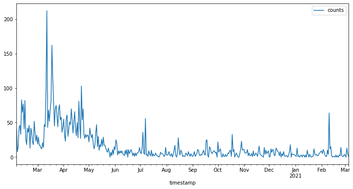

```python
daily_rev_counts.plot(figsize=(12,6))
```

#### Interpretation

We can see that there's a considerable increase in the revision times is in mid-March, even more than 200 reevision records at its peak. If we compare [the number of new cases globally](https://www.nytimes.com/interactive/2020/world/coronavirus-maps.html), we can find that the global new cases statistics can correspond to this revision chart. So there is some relation between the outbreak in March around the world and the revision activity.